# Untitled

2023-10-31

# Disenos aleatorios

## Espectofotómetro

Se está desarrollando un nuevo modelo de espectrofotómetro para uso en laboratorios clínicos con el objetivo de cuantificar sustancias y microorganismos. Se quiere evaluar el funcionamiento de estos instrumentos sabiendo que un componente crítico del desempeño es la consistencia de las mediciones de un día a otro, y de una máquina a otra. Se quiere saber si la variabilidad de las mediciones entre las máquinas operadas durante varios días está dentro de los estándares aceptables. Hay dos escenarios, en el primero se toman 4 máquinas asumiendo que solo existen esas 4 máquinas, mientras que en el segundo se seleccionan aleatoriamente 4 máquinas etiquetadas como A, B, C y D de un conjunto mucho mayor de máquinas. Cada día se preparan 8 replicaciones de muestras de suero en sangre con el mismo lote de reactivos para todo el experimento. Dos muestras de suero se asignan aleatoriamente a cada una de las cuatro máquinas en cada uno de los 4 días resultando en dos repeticiones de cada combinación día-máquina. Se miden los niveles de triglicéridos (mg/dl) en las muestras de suero. Los datos se muestran a continuación: 1. Introduzca los datos. Defina dia y maquina como factor.

```r
trigli=c(142.3, 144.0, 148.6, 146.9, 142.9, 147.4, 133.8,
133.2, 134.9, 146.3, 145.2, 146.3, 125.9, 127.6,
108.9, 107.5, 148.6, 156.5, 148.6, 153.1, 135.5,
138.9, 132.1, 149.7, 152.0, 151.4, 149.7, 152.0,
142.9, 142.3, 141.7, 141.2)
dia=factor(rep(1:4,each=8))
maq=factor(rep(c("A","B","C","D"),4,each=2))
base=data.frame(trigli,dia,maq)
```

2. Haga gráficos para ver el comportamiento de la respuesta de día a día y de máquina a máquina. Haga un análisis descriptivo.

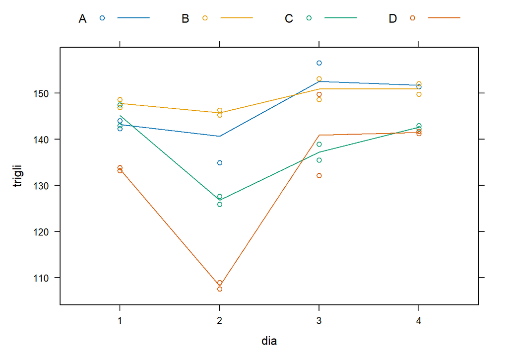

```r
library(lattice)
xyplot(trigli~dia,groups = maq,type=c("p","a"),data = base,auto.key = list(columns=4))
```

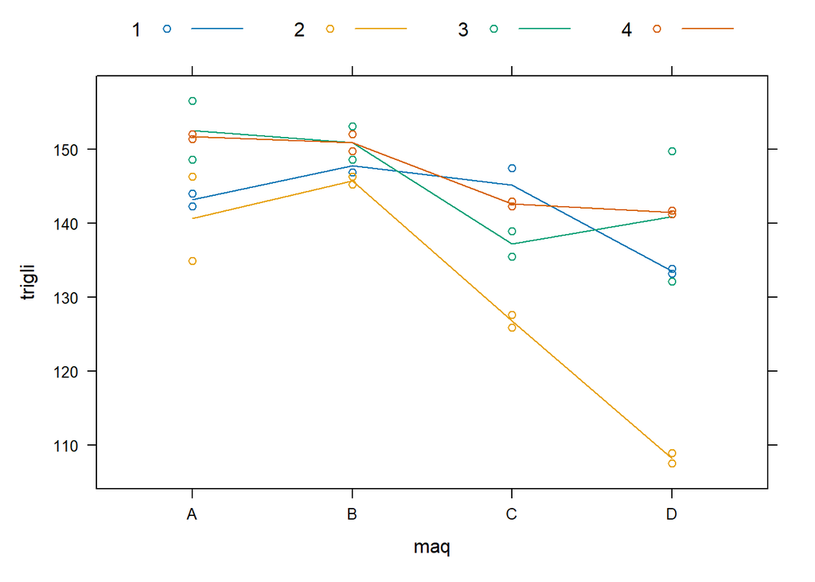

```r
xyplot(trigli~maq,groups = dia,type=c("p","a"),data = base,auto.key = list(columns=4))
```

3. Ajuste el modelo que tiene en la parte de efectos fijos el intercepto y la máquina, mientras que en la parte de efectos aleatorios incluye el día (1|dia) y la interacción (1|dia:maq). Recuerde que siempre que al menos uno de los factores tenga efectos aleatorios, la interacción se tiene también efectos aleatorios. • Obtenga las estimaciones de las variancias correspondientes a este modelo tanto en R como manualmente.

```r
library(lme4)
mod1=lmer(trigli~1+maq+(1|dia)+(1|dia:maq),data = base)
summary(mod1)
```

```
## Linear mixed model fit by REML ['lmerMod']
## Formula: trigli ~ 1 + maq + (1 | dia) + (1 | dia:maq)
##    Data: base
##
## REML criterion at convergence: 192.5
##
## Scaled residuals:
##      Min       1Q   Median       3Q      Max
## -1.76445 -0.39754  0.04255  0.21114  2.39603
##
## Random effects:
##  Groups   Name        Variance Std.Dev.
##  dia:maq  (Intercept) 34.72    5.892
##  dia      (Intercept) 44.69    6.685
##  Residual             17.90    4.230
## Number of obs: 32, groups:  dia:maq, 16; dia, 4
##
## Fixed effects:
##             Estimate Std. Error t value
## (Intercept)  147.000      4.700  31.278
## maqB           1.800      4.673   0.385
## maqC          -9.075      4.673  -1.942
## maqD         -15.987      4.673  -3.421
##
## Correlation of Fixed Effects:
##      (Intr) maqB   maqC
## maqB -0.497
## maqC -0.497  0.500
## maqD -0.497  0.500  0.500
```

• Obtenga e interprete los intervalos de 95% de confianza para las desviaciones estándar. La estimaciones van en el orden en que aparecen en el summary, es decir, desviación estándar de interacción (sig01), desviación estándar de días (sig02) y desviación estándar de error (sigma).

```r
confint(profile(mod1))
```

```
##                  2.5 %     97.5 %
## .sig01        2.072849   8.582628
## .sig02        1.645939  15.576843
## .sigma        3.100570   6.257757
## (Intercept) 137.839400 156.160596
## maqB         -6.810546  10.410547
## maqC        -17.685546  -0.464453
## maqD        -24.598046  -7.376953
```

4. Ajuste un modelo similar donde la máquina tiene efectos aleatorios, pues se tienen muchas máquinas y estas 4 son una muestra. • Obtenga las estimaciones de las variancias correspondientes a este modelo y compárelas con las obtenidas anteriormente.

```r
mod2=lmer(trigli~(1|maq)+(1|dia)+(1|dia:maq),data = base)
summary(mod2)
```

```
## Linear mixed model fit by REML ['lmerMod']
## Formula: trigli ~ (1 | maq) + (1 | dia) + (1 | dia:maq)
##    Data: base
##
## REML criterion at convergence: 215
##
## Scaled residuals:
##      Min       1Q   Median       3Q      Max
## -1.84283 -0.35581  0.03485  0.20700  2.31766
##
## Random effects:
##  Groups   Name        Variance Std.Dev.
##  dia:maq  (Intercept) 34.72    5.892
##  dia      (Intercept) 44.69    6.685
##  maq      (Intercept) 57.72    7.597
##  Residual             17.90    4.230
## Number of obs: 32, groups:  dia:maq, 16; dia, 4; maq, 4
##
## Fixed effects:
##             Estimate Std. Error t value
## (Intercept)  141.184      5.323   26.52
```

## Colorantes

En una investigación sobre la elaboración de un colorante se sospecha que la variación del producto final puede estar siendo determinada por variaciones en la calidad de un producto intermedio (ácido H). Se quiere encontrar cuánta de la variación entre lote y lote del ácido H contribuye a la variación en la producción del colorante hecho con este producto. Se analiza la variabilidad total y se separa la variabilidad que introducen los lotes que son materia prima, de tal forma que la variabilidad restante es atribuida al proceso productivo. Por lo tanto, si la variabilidad total está fuertemente determinada por la variabilidad de los lotes, el productor de colorantes debe llamar la atención al proveedor del ácido H para lograr que su producto sea más estable. Se toman seis lotes de producto intermedio (ácido H) y de cada uno se hacen cinco preparaciones de colorante en el laboratorio. Se determina la producción de cada preparación mediante gramos de color estándar.

1. Abra el archivo colorantes.Rdata

```r
load("bases/colorantes.Rdata")
str(base)
```

```
## 'data.frame':    30 obs. of  2 variables:
##  $ lote: Factor w/ 6 levels "A","B","C","D",..: 1 1 1 1 1 2 2 2 2 2 ...
##  $ prod: num  1545 1440 1440 1520 1580 ...
```

2. Haga un gráfico para ver el comportamiento de la respuesta de lote a lote. Haga un análisis descriptivo. En la librería ggplot2 puede usar la función qplot de la siguiente forma: ggplot(base,aes(X,Y))+ geom_boxplot().

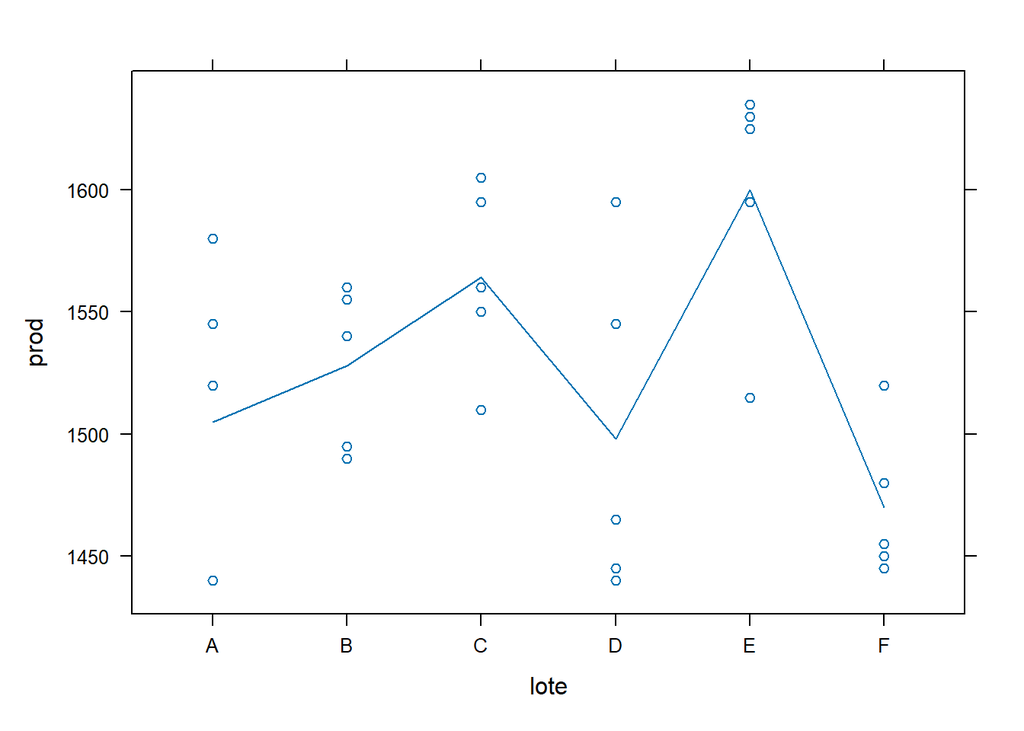

```r
library(lattice)
xyplot(prod~lote,type=c("a","p"),data = base)
```

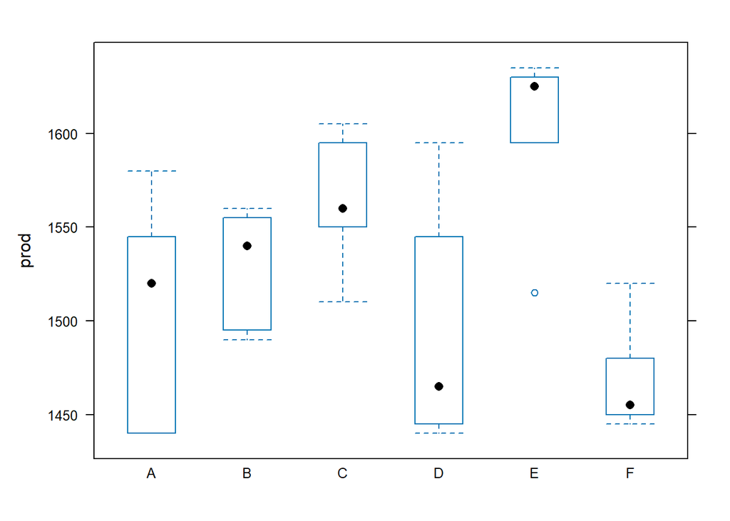

```r
bwplot(prod~lote,data=base)
```

• Discuta cómo se observa la variabilidad intra-sujeto y la variabilidad inter-sujeto. 3. Ajuste el modelo mixto con la función lmer de la librería lme4. El modelo tiene en la parte de efectos fijos solo el intercepto (ponga un uno pero no es indispensable) y en la parte de efectos aleatorios el lote (1|lote) – en esta parte el 1 representa el promedio: mod1=lmer(prod~1+(1|lote)) es equivalente a mod1=lmer(prod~(1|lote)). • Obtenga del summary del mod1 las estimaciones de las variancias correspondientes a este modelo.

```r
mod1=lmer(prod~(1|lote),data = base)
summary(mod1)
```

```
## Linear mixed model fit by REML ['lmerMod']
## Formula: prod ~ (1 | lote)
##    Data: base
##
## REML criterion at convergence: 319.7
##
## Scaled residuals:
##     Min      1Q  Median      3Q     Max
## -1.4117 -0.7634  0.1418  0.7792  1.8296
##
## Random effects:
##  Groups   Name        Variance Std.Dev.
##  lote     (Intercept) 1764     42.00
##  Residual             2451     49.51
## Number of obs: 30, groups:  lote, 6
##
## Fixed effects:
##             Estimate Std. Error t value
## (Intercept)  1527.50      19.38    78.8
```

• Asegúrese que puede obtener manualmente esas estimaciones a partir del anova de un modelo lineal. 4. Obtenga los intervalos de confianza para los parámetros del modelo (por default R usa un nivel de confianza de 0.95): confint(profile(mod1),level=0.95). En el resultado se debe interpretar sigma como la desviación estándar del error y sigma01 la desviación estándar de lote.

```r
lote=1764
err=2451
(lote/(err+lote))*100
```

```
## [1] 41.85053
```

```r
confint(profile(mod1))
```

```
##                  2.5 %     97.5 %
## .sig01        12.19854   84.06305
## .sigma        38.22998   67.65770
## (Intercept) 1486.45150 1568.54849
```

## Escarabajos

En un estudio se quería identificar cuál tipo de recolecta es mejor para registrar la diversidad de sexo en una especie de escarabajos. Se realizaron recolectas de escarabajos nocturnos con dos métodos: 1) usando alumbrado público y 2) utilizando lámparas. Los muestreos se hicieron sistemáticamente (hora y media a partir de la penumbra) durante los meses de abril a junio en cinco parcelas de cultivo en la zona de San Cristóbal de Las Casas, Chiapas. Se registró el sexo de los escarabajos recolectados para determinar si en un tipo de recolecta la proporción de cada sexo era diferente.

Ejercicios 1. Cargue los datos en el archivo escarabajos.Rdata. Defina parcela como factor.

```r
load("bases/escarabajos.Rdata")
str(base)
```

```
## 'data.frame':    10 obs. of  4 variables:
##  $ parcela: int  1 2 3 4 5 1 2 3 4 5
##  $ tipo   : Factor w/ 2 levels "L","AP": 1 1 1 1 1 2 2 2 2 2
##  $ M      : int  234 31 979 65 7 11 12 12 7 17
##  $ H      : int  356 6 900 63 5 35 8 18 8 10
```

```r
base$parcela=factor(base$parcela)
```

• Identifique la variable respuesta y comente sobre la distribución condicional que tiene esta variable. • Justifique si las parcelas representan un efecto fijo o aleatorio. • Represente gráficamente los datos y observe si se puede esperar un efecto del método de recolecta.

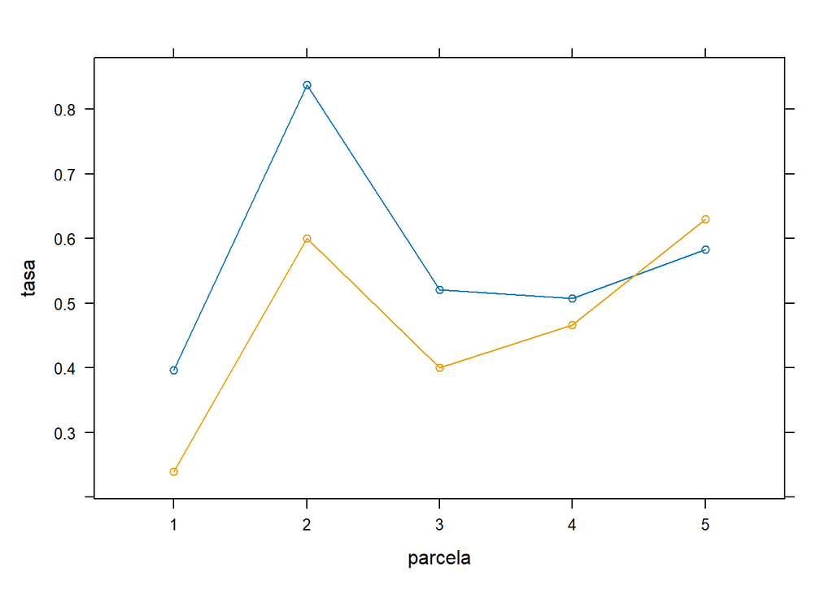

```r
xyplot(M/(M+H)~parcela,groups = tipo,type=c("a","p"),data = base,ylab = "tasa")
```

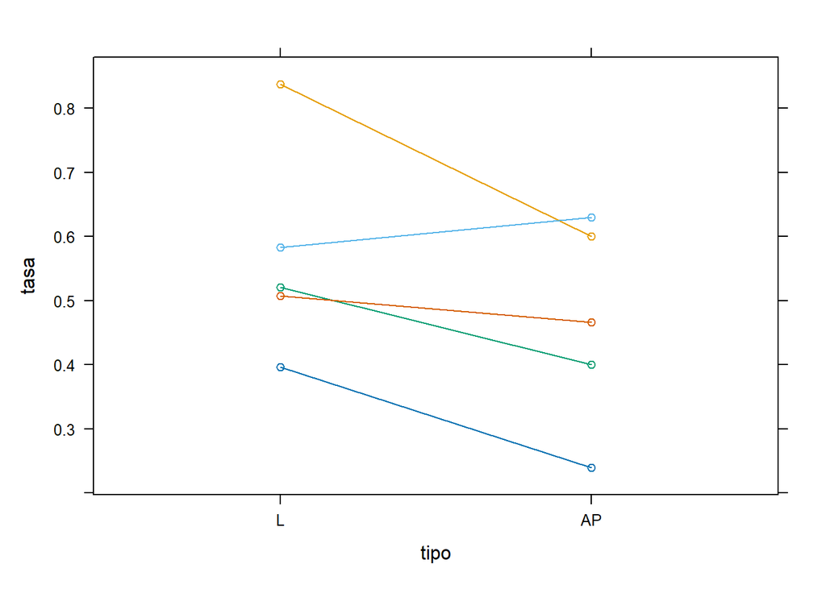

```r
xyplot(M/(M+H)~tipo,groups =parcela,type=c("a","p"),data = base,ylab = "tasa")
```

2. Tome las parcelas como bloques fijos y ajuste el modelo logístico sin interacción con glm. Ponga atención al modelo que está usando en R (suma nula o tratamiento referencia). • Interprete la razón de propensiones (OR) resultante. Debe tener claro cuál probabilidad es la que está obteniendo (de machos o hembras). Esto dependerá de la forma en que especificó su modelo.

```r
options(contrasts=c("contr.sum","contr.poly"))
mod0=glm(cbind(M,H)~tipo+parcela,family="binomial",data=base)
coef=mod0$coefficients
contrasts(base$tipo)
```

```
##    [,1]
## L     1
## AP   -1
```

```r
#contraste
tipo.l=c(1,1,0,0,0,0)
tipo.ap=c(1,-1,0,0,0,0)
contra=tipo.l-tipo.ap
eta=t(contra)%*%coef
eta=abs(eta)
exp(eta)
```

```
##          [,1]
## [1,] 1.744763
```

3. Realice la prueba LRT para determinar si existe un efecto del tipo de recolecta en la proporción de machos (o hembras) capturados.

```r
mod01=glm(cbind(M,H)~tipo+parcela,family="binomial",data=base)
mod02=glm(cbind(M,H)~parcela,family="binomial",data=base)
anova(mod01,mod02,test="LRT")
```

```
## Analysis of Deviance Table
##
## Model 1: cbind(M, H) ~ tipo + parcela
## Model 2: cbind(M, H) ~ parcela
##   Resid. Df Resid. Dev Df Deviance Pr(>Chi)
## 1         4     3.0608
## 2         5    10.4913 -1  -7.4305 0.006413 **
## ---
## Signif. codes:  0 '***' 0.001 '**' 0.01 '*' 0.05 '.' 0.1 ' ' 1
```

```r
drop1(mod01,test="LRT")
```

```
## Single term deletions
##
## Model:
## cbind(M, H) ~ tipo + parcela
##         Df Deviance     AIC    LRT  Pr(>Chi)
## <none>        3.061  59.706
## tipo     1   10.491  65.137  7.431  0.006413 **
## parcela  4   61.688 110.333 58.627 5.636e-12 ***
## ---
## Signif. codes:  0 '***' 0.001 '**' 0.01 '*' 0.05 '.' 0.1 ' ' 1
```

4. Lo que se hizo anteriormente no es correcto, ya que no se está considerando la parcela como un elemento aleatorio sino fijo, como si solo existieran esas parcelas. Ahora tome la parcela como un efecto aleatorio y ajuste el modelo usando la función glmer de la librería lme4. Obtenga el OR y compárelo con el obtenido anteriormente.

```r
mod1=glmer(cbind(M,H)~tipo+(1|parcela),family="binomial",data=base)
coef=summary(mod1)$coefficients[,1]
contrasts(base$tipo)
```

```
##    [,1]
## L     1
## AP   -1
```

```r
#contraste
tipo.l=c(1,1)
tipo.ap=c(1,-1)
contra=tipo.l-tipo.ap
eta=t(contra)%*%coef
eta=abs(eta)
exp(eta)
```

```
##          [,1]
## [1,] 1.629267
```

• En el gráfico anterior, se puede apreciar uan posible interacción entre parcela y tipo de recolecta. Usualmente se asume que no existe interacción cuando se tiene un diseño con bloques, porque típicamente esta interacción no se puede verificar al tener solo una observación por tratamiento y bloque. En este caso sí se puede verificar. Ajuste un modelo donde incluya la interacción, observe la estimación de la varianza de los efectos de interacción y relaciónelo con el mensaje que da R al ajustar este modelo.

```r
mod11=glmer(cbind(M,H)~tipo+(1|parcela),family="binomial",data=base)
mod12=glmer(cbind(M,H)~tipo+(1|parcela)+(1|parcela:tipo),family="binomial",data=base)
```

```
## boundary (singular) fit: see help('isSingular')
```

• Realice la prueba adecuada para determinar si se debe considerar esta interacción.

```r
anova(mod11,mod12,test="LRT")
```

```
## Data: base
## Models:
## mod11: cbind(M, H) ~ tipo + (1 | parcela)
## mod12: cbind(M, H) ~ tipo + (1 | parcela) + (1 | parcela:tipo)
##       npar    AIC    BIC  logLik deviance Chisq Df Pr(>Chisq)
## mod11    3 73.223 74.131 -33.612   67.223
## mod12    4 75.223 76.434 -33.612   67.223     0  1          1
```

• Vuelva al modelo sin interacción y realice la prueba adecuada para determinar si existe un efecto del tipo de recolecta.

```r
mod11=glmer(cbind(M,H)~tipo+(1|parcela),family="binomial",data=base)
mod13=glmer(cbind(M,H)~(1|parcela),family="binomial",data=base)
anova(mod11,mod13,test="LRT")#!!! hay alguna diferencia con el orden de modelos pequeno, grande
```

```
## Data: base
## Models:
## mod13: cbind(M, H) ~ (1 | parcela)
## mod11: cbind(M, H) ~ tipo + (1 | parcela)
##       npar    AIC    BIC  logLik deviance  Chisq Df Pr(>Chisq)
## mod13    2 77.050 77.655 -36.525   73.050
## mod11    3 73.223 74.131 -33.612   67.223 5.8267  1    0.01578 *
## ---
## Signif. codes:  0 '***' 0.001 '**' 0.01 '*' 0.05 '.' 0.1 ' ' 1
```

```r
drop1(mod11,test = "Chisq") #!!! porque en este caso si funciona
```

```
## Single term deletions
##
## Model:
## cbind(M, H) ~ tipo + (1 | parcela)
##        npar    AIC    LRT Pr(Chi)
## <none>      73.223
## tipo      1 77.050 5.8267 0.01578 *
## ---
## Signif. codes:  0 '***' 0.001 '**' 0.01 '*' 0.05 '.' 0.1 ' ' 1
```

• Construya intervalos de 95% para el OR obtenido con cada modelo (con bloques fijos y con efectos aleatorios). Compárelos.

```r
#Para fijos
mod01=glm(cbind(M,H)~tipo+parcela,family="binomial",data=base)
##
exp(confint(mod01)*2)
```

```
##                 2.5 %     97.5 %
## (Intercept) 0.8065064  1.9192735
## tipo1       1.1671858  2.6457826
## parcela1    0.1192017  0.3167817
## parcela2    2.4937547 19.6343397
## parcela3    0.3439399  0.8611008
## parcela4    0.2765428  1.0234138
```

```r
##
coef=mod01$coefficients
tipo.l=c(1,1,0,0,0,0)
tipo.ap=c(1,-1,0,0,0,0)
contra=tipo.l-tipo.ap
eta=t(contra)%*%coef
eta=abs(eta)
ee=sqrt(diag(t(contra)%*%vcov(mod01)%*%contra))
#valor qz
qz=qnorm(1-0.05/2)
ic.sup=exp(eta+qz*ee)
ic.inf=exp(eta-qz*ee)
round(cbind(ic.inf,ic.sup),4)
```

```
##        [,1]  [,2]
## [1,] 1.1601 2.624
```

```r
#Para aleatorios
mod11=glmer(cbind(M,H)~tipo+(1|parcela),family="binomial",data=base)
exp(confint(mod11)*2)
```

```
## Computing profile confidence intervals ...
```

```
##                 2.5 %    97.5 %
## .sig01      1.7265565 14.123610
## (Intercept) 0.3179016  4.493898
## tipo1       1.0948738  2.459113
```

```r
coef=summary(mod11)$coef[,1]
##
tipo.l=c(1,1)
tipo.ap=c(1,-1)
contra=tipo.l-tipo.ap
eta=t(contra)%*%coef
eta=abs(eta)
vcov=c(0.075193182,0.010592613)
ee=sqrt(t(contra)%*%vcov%*%contra)
#valor qz
qz=qnorm(1-0.05/2)
ic.sup=exp(eta+qz*ee[2])
ic.inf=exp(eta-qz*ee[2])
round(cbind(ic.inf,ic.sup),4)
```

```
##        [,1]  [,2]
## [1,] 1.0884 2.439
```

5. Para terminar es importante escribir el modelo teórico que se está usando. Como se trata de un modelo con una función de enlace logística, no conviene escribirlo en función de cada observación sino en función de la esperanza. • Observe el summary del modelo. Note que solo se ha estimado un componente de varianza ya que en estos modelos no se incluye la varianza del error.

```r
summary(mod11)
```

```
## Generalized linear mixed model fit by maximum likelihood (Laplace
##   Approximation) [glmerMod]
##  Family: binomial  ( logit )
## Formula: cbind(M, H) ~ tipo + (1 | parcela)
##    Data: base
##
##      AIC      BIC   logLik deviance df.resid
##     73.2     74.1    -33.6     67.2        7
##
## Scaled residuals:
##      Min       1Q   Median       3Q      Max
## -0.72588 -0.38744 -0.01966  0.39110  1.26947
##
## Random effects:
##  Groups  Name        Variance Std.Dev.
##  parcela (Intercept) 0.315    0.5612
## Number of obs: 10, groups:  parcela, 5
##
## Fixed effects:
##             Estimate Std. Error z value Pr(>|z|)
## (Intercept)  0.06283    0.27421   0.229   0.8188
## tipo1        0.24407    0.10292   2.371   0.0177 *
## ---
## Signif. codes:  0 '***' 0.001 '**' 0.01 '*' 0.05 '.' 0.1 ' ' 1
##
## Correlation of Fixed Effects:
##       (Intr)
## tipo1 -0.173
```

• ¿Se puede obtener a partir de los resultados una estimación de la probabilidad de obtener un macho con un cierto tipo de alumbrado en general en la población?

### Diseño con 2 niveles y factor fijo en ambos niveles (papel)

Un fabricante de papel está interesado en tres métodos para preparar la pulpa y cuatro temperaturas de cocción de la pulpa. Aunque la temperatura es una variable continua, solo se van a estudiar 4 temperaturas.

El fabricante desea estudiar el efecto del método y de la temperatura sobre la resistencia a la tensión del papel, que es el esfuerzo máximo a tensión obtenido durante una prueba hasta la ruptura bajo unas condiciones prescritas. El esfuerzo es expresado como la fuerza por unidad del ancho de la muestra puesta a prueba, medido en kg/cm. El experimento se lleva a cabo de la siguiente forma: + Produce tres lotes de pulpa con cada uno de los tres métodos que está estudiando en un orden aleatorio. En total produce 9 lotes de pulpa. + Cada vez que produce un lote lo divide en cuatro partes o muestras y realiza la cocción de cada muestra a una temperatura diferente. 1. Utilice los datos que se encuentran en el archivo papel.Rdata. Asegúrese que están bien definidos los factores método y temperatura.

```r
load("bases/papel.Rdata")
str(base)
```

```
## 'data.frame':    36 obs. of  4 variables:
##  $ res   : int  30 36 35 37 42 34 38 41 40 31 ...
##  $ metodo: int  1 1 1 1 2 2 2 2 2 2 ...
##  $ temp  : int  200 275 225 250 275 200 250 225 275 200 ...
##  $ lote  : int  1 1 1 1 2 2 2 2 3 3 ...
```

```r
base$metodo=factor(base$metodo)
levels(base$metodo)=c("M1","M2","M3")
base$temp=factor(base$temp)
```

- La variable lote indica los lotes de pulpa, y se enumeran de 1 a 9 para diferenciar todos los lotes. Ponga juntas las variables metodo y lote para observar la correspondencia de los lotes con los métodos.
- Haga una representación gráfica de los datos para ver el comportamiento de la respuesta según método y temperatura. Analice primero la interacción entre método y temperatura. Use type=“a” en la función xyplot. En los diseños de parcela divididas se pone más énfasis al factor que está en la subparcela, por lo que ese factor debe colocarse en groups, mientras que el factor de parcela se coloca en el eje X.

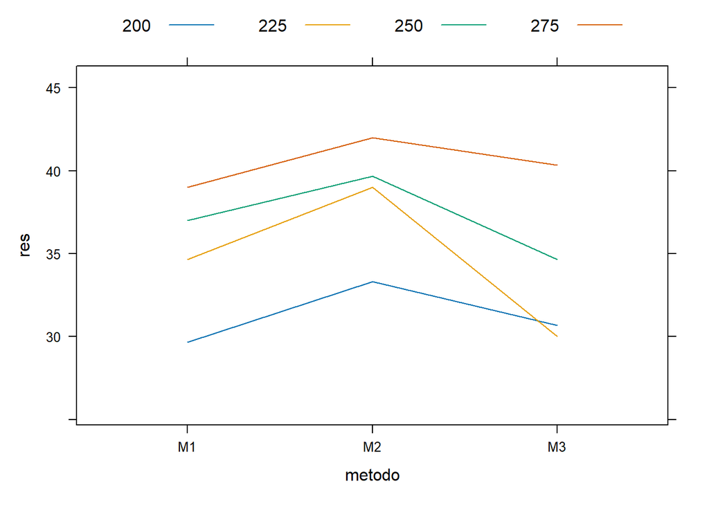

```r
library(lattice)
xyplot(res~metodo,groups=temp,type=c("a"),data = base,auto.key = list(columns=4))
```

- Basado en lo que ve en el gráfico, se espararía un efecto de la temperatura?
- ¿Qué implicaciones tendría una interacción entre método y temperatura?
2. Haga el análisis usando la función lmer de la librería lme4. Las unidades del Nivel 2 son los lotes, mientras que en el Nivel 1 se tiene cada muestra dentro del lote. Los lotes son aleatorios, y la parte aleatoria se separan con un + de la parte fija del modelo y se pone entre paréntesis (1|lote). La instrucción completa debe quedar de la siguiente forma: lmer(Y~F2*F1+(1|lote)), donde F2 indica el factor del Nivel 2 que, en este caso, es el método y F1 es el factor del Nivel 1 que es la temperatura.

```r
library(lme4)
mod1=lmer(res~metodo*temp+(1|lote),data = base)
```

- La función drop1 permite probar hipótesis sobre los términos fijos, y debe usarse con test=“Chisq” para hacer la prueba de razón de verosimilitud (LRT). Haga la prueba de la hipótesis sobre la interacción. En esta prueba también se obtiene el AIC de cada modelo y puede decidirse a partir de la comparación de los AIC, recordando que se prefiere el modelo con el menor AIC.

```r
drop1(mod1,test = "Chisq")
```

```
## Single term deletions
##
## Model:
## res ~ metodo * temp + (1 | lote)
##             npar    AIC    LRT Pr(Chi)
## <none>           179.97
## metodo:temp    6 183.32 15.349 0.01771 *
## ---
## Signif. codes:  0 '***' 0.001 '**' 0.01 '*' 0.05 '.' 0.1 ' ' 1
```

3. Asumiendo que hay interacción entre METODO y TEMPERATURA, se pueden comparar las temperaturas dentro de cada método haciendo el ajuste de Bonferroni. Para esto se usa la función emmeans en la librería con el mismo nombre. Se debe indicar emmeans(mod, pairwise~F1|F2, adjust=“bonferroni”).

```r
library(emmeans)
emmeans(mod1, pairwise~temp|metodo, adjust="bonferroni")
```

```
## $emmeans
## metodo = M1:
##  temp emmean   SE   df lower.CL upper.CL
##  200    29.7 1.58 15.3     26.3     33.0
##  225    34.7 1.58 15.3     31.3     38.0
##  250    37.0 1.58 15.3     33.6     40.4
##  275    39.0 1.58 15.3     35.6     42.4
##
## metodo = M2:
##  temp emmean   SE   df lower.CL upper.CL
##  200    33.3 1.58 15.3     30.0     36.7
##  225    39.0 1.58 15.3     35.6     42.4
##  250    39.7 1.58 15.3     36.3     43.0
##  275    42.0 1.58 15.3     38.6     45.4
##
## metodo = M3:
##  temp emmean   SE   df lower.CL upper.CL
##  200    30.7 1.58 15.3     27.3     34.0
##  225    30.0 1.58 15.3     26.6     33.4
##  250    34.7 1.58 15.3     31.3     38.0
##  275    40.3 1.58 15.3     37.0     43.7
##
## Degrees-of-freedom method: kenward-roger
## Confidence level used: 0.95
##
## $contrasts
## metodo = M1:
##  contrast          estimate   SE df t.ratio p.value
##  temp200 - temp225   -5.000 1.68 18  -2.983  0.0478
##  temp200 - temp250   -7.333 1.68 18  -4.376  0.0022
##  temp200 - temp275   -9.333 1.68 18  -5.569  0.0002
##  temp225 - temp250   -2.333 1.68 18  -1.392  1.0000
##  temp225 - temp275   -4.333 1.68 18  -2.586  0.1119
##  temp250 - temp275   -2.000 1.68 18  -1.193  1.0000
##
## metodo = M2:
##  contrast          estimate   SE df t.ratio p.value
##  temp200 - temp225   -5.667 1.68 18  -3.381  0.0200
##  temp200 - temp250   -6.333 1.68 18  -3.779  0.0082
##  temp200 - temp275   -8.667 1.68 18  -5.171  0.0004
##  temp225 - temp250   -0.667 1.68 18  -0.398  1.0000
##  temp225 - temp275   -3.000 1.68 18  -1.790  0.5417
##  temp250 - temp275   -2.333 1.68 18  -1.392  1.0000
##
## metodo = M3:
##  contrast          estimate   SE df t.ratio p.value
##  temp200 - temp225    0.667 1.68 18   0.398  1.0000
##  temp200 - temp250   -4.000 1.68 18  -2.387  0.1691
##  temp200 - temp275   -9.667 1.68 18  -5.768  0.0001
##  temp225 - temp250   -4.667 1.68 18  -2.785  0.0734
##  temp225 - temp275  -10.333 1.68 18  -6.166  <.0001
##  temp250 - temp275   -5.667 1.68 18  -3.381  0.0200
##
## Degrees-of-freedom method: kenward-roger
## P value adjustment: bonferroni method for 6 tests
```

```r
#!!! profundizar en este diseno no tenemos claro que representa lote1
load("bases/papel2.Rdata")
str(base)
```

```
## 'data.frame':    36 obs. of  6 variables:
##  $ res   : int  30 35 37 36 34 41 38 42 29 37 ...
##  $ dia   : int  1 1 1 1 1 1 1 1 1 1 ...
##  $ metodo: int  1 1 1 1 2 2 2 2 3 3 ...
##  $ temp  : int  200 225 250 275 200 225 250 275 200 225 ...
##  $ lote  : int  1 1 1 1 1 1 1 1 1 1 ...
##  $ lote1 : int  1 1 1 1 2 2 2 2 3 3 ...
```

```r
base$metodo=factor(base$metodo)
levels(base$metodo)=c("M1","M2","M3")
base$temp=factor(base$temp)
base$dia=factor(base$dia)
base$lote=factor(base$lote)
base$lote1=factor(base$lote1)
```

- Represente los datos usando xyplot con lote en el eje X, con páneles separados por método y dentro de cada panel líneas para cada temperatura.

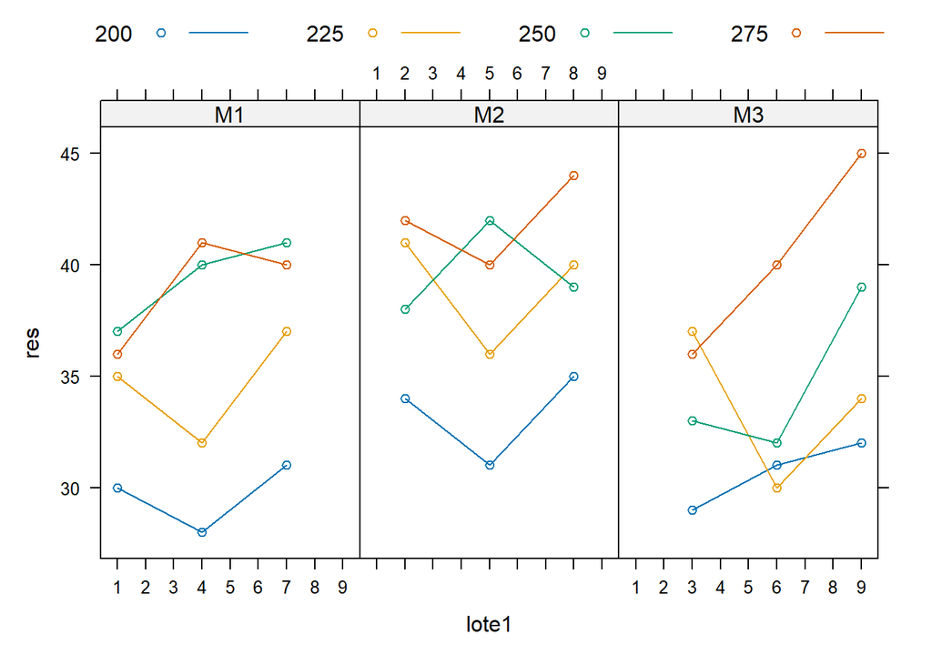

```r
xyplot(res~lote1|metodo,groups=temp,type=c("a","p"),data = base,auto.key = list(columns=4))
```

2. Empiece con el modelo con interacción entre metodo y temp e incluya dia como bloque. Hágalo directamente con la función lmer y agregue el día como un término aleatorio de Nivel 3, para esto indique (1|dia/lote1), de esta forma se está diciendo que lo lotes son de Nivel 2 y están dentro de los días que son de Nivel 3.

```r
mod1=lmer(res~metodo*temp+(1|dia/lote1),data = base)
```

```
## boundary (singular) fit: see help('isSingular')
```

- Pruebe la hipótesis de no interacción con LRT.

```r
drop1(mod1,test = "Chisq")
```

```
## boundary (singular) fit: see help('isSingular')
```

```
## Single term deletions
##
## Model:
## res ~ metodo * temp + (1 | dia/lote1)
##             npar    AIC    LRT Pr(Chi)
## <none>           184.06
## metodo:temp    6 181.74 9.6848  0.1386
```

```r
mod11=lmer(res~metodo*temp+(1|dia/lote1),data = base)
```

```
## boundary (singular) fit: see help('isSingular')
```

```r
mod12=lmer(res~metodo+temp+(1|dia/lote1),data = base)
```

```
## boundary (singular) fit: see help('isSingular')
```

```r
anova(mod11,mod12,test="LRT")
```

```
## refitting model(s) with ML (instead of REML)
```

```
## Data: base
## Models:
## mod12: res ~ metodo + temp + (1 | dia/lote1)
## mod11: res ~ metodo * temp + (1 | dia/lote1)
##       npar    AIC    BIC  logLik deviance  Chisq Df Pr(>Chisq)
## mod12    9 181.74 195.99 -81.870   163.74
## mod11   15 184.06 207.81 -77.028   154.06 9.6848  6     0.1386
```

3. Use el modelo sin interacción y pruebe si hay un efecto del método y de la temperatura.

```r
mod12=lmer(res~metodo+temp+(1|dia/lote1),data = base)
```

```
## boundary (singular) fit: see help('isSingular')
```

```r
drop1(mod12,test = "Chisq")
```

```
## boundary (singular) fit: see help('isSingular')
```

```
## Single term deletions
##
## Model:
## res ~ metodo + temp + (1 | dia/lote1)
##        npar    AIC    LRT   Pr(Chi)
## <none>      181.74
## metodo    2 188.22 10.481  0.005298 **
## temp      3 217.27 41.531 5.044e-09 ***
## ---
## Signif. codes:  0 '***' 0.001 '**' 0.01 '*' 0.05 '.' 0.1 ' ' 1
```

```r
#con metodo de momentos
mod12=lmer(res~metodo+temp+(1|dia/lote1),data = base)
```

```
## boundary (singular) fit: see help('isSingular')
```

```r
mod13=lmer(res~temp+(1|dia/lote1),data = base)
anova(mod13,mod12,test="LRT")
```

```
## refitting model(s) with ML (instead of REML)
```

```
## Data: base
## Models:
## mod13: res ~ temp + (1 | dia/lote1)
## mod12: res ~ metodo + temp + (1 | dia/lote1)
##       npar    AIC    BIC  logLik deviance  Chisq Df Pr(>Chisq)
## mod13    7 188.22 199.31 -87.111   174.22
## mod12    9 181.74 195.99 -81.870   163.74 10.481  2   0.005298 **
## ---
## Signif. codes:  0 '***' 0.001 '**' 0.01 '*' 0.05 '.' 0.1 ' ' 1
```

```r
mod12=lmer(res~metodo+temp+(1|dia/lote1),data = base)
```

```
## boundary (singular) fit: see help('isSingular')
```

```r
mod13=lmer(res~metodo+(1|dia/lote1),data = base)
```

```
## boundary (singular) fit: see help('isSingular')
```

```r
anova(mod13,mod12,test="LRT")
```

```
## refitting model(s) with ML (instead of REML)
```

```
## Data: base
## Models:
## mod13: res ~ metodo + (1 | dia/lote1)
## mod12: res ~ metodo + temp + (1 | dia/lote1)
##       npar    AIC    BIC  logLik deviance  Chisq Df Pr(>Chisq)
## mod13    6 217.27 226.77 -102.64   205.27
## mod12    9 181.74 195.99  -81.87   163.74 41.531  3  5.044e-09 ***
## ---
## Signif. codes:  0 '***' 0.001 '**' 0.01 '*' 0.05 '.' 0.1 ' ' 1
```

- Como se vio que el método tiene un efecto sobre la resistencia promedio, es importante comparar los promedios de resistencia entre los diferentes métodos. Haga un gráfico para comparar la resistencia según los diferentes métodos.

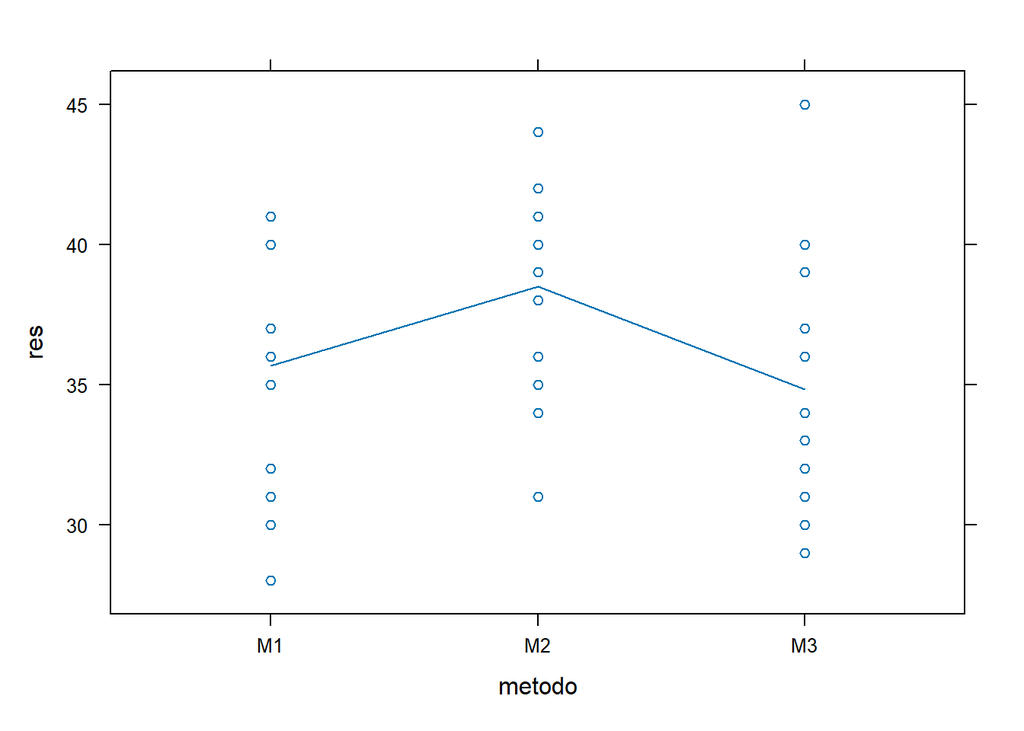

```r
xyplot(res~metodo,type=c("a","p"),data=base)
```

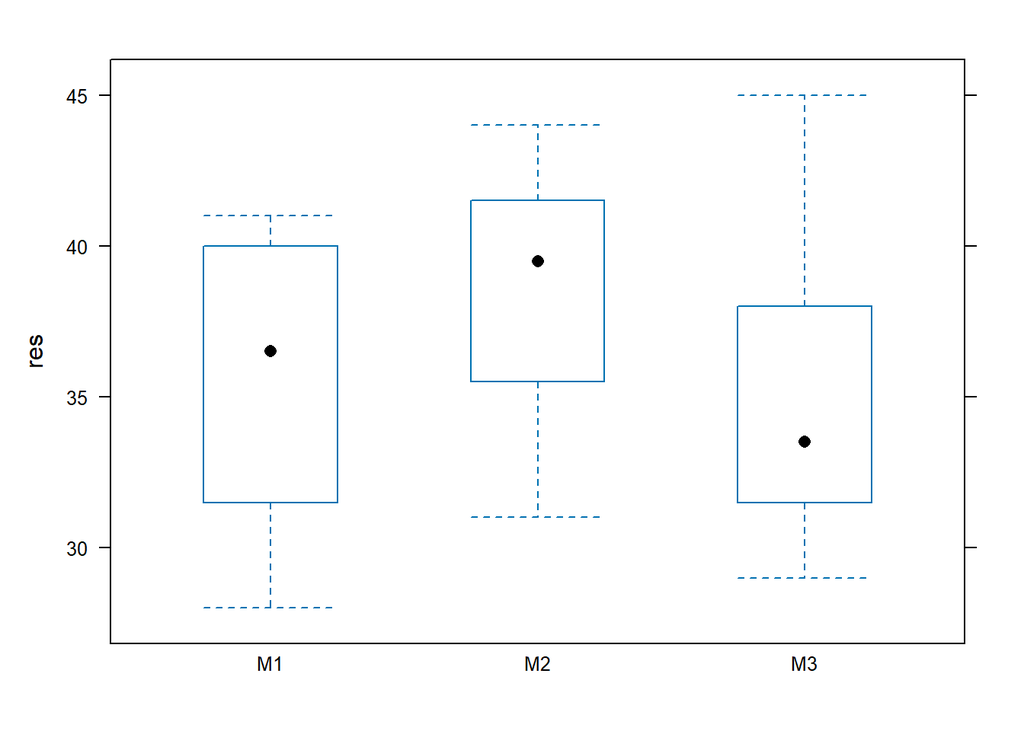

```r
bwplot(res~metodo,data = base)
```

- Haga la comparación usando la función emmeans.

```r
emmeans(mod12, pairwise~metodo, adjust="bonferroni")
```

```
## $emmeans
##  metodo emmean   SE   df lower.CL upper.CL
##  M1       35.7 1.05 3.69     32.6     38.7
##  M2       38.5 1.05 3.69     35.5     41.5
##  M3       34.8 1.05 3.69     31.8     37.9
##
## Results are averaged over the levels of: temp
## Degrees-of-freedom method: kenward-roger
## Confidence level used: 0.95
##
## $contrasts
##  contrast estimate    SE df t.ratio p.value
##  M1 - M2    -2.833 0.986  4  -2.873  0.1360
##  M1 - M3     0.833 0.986  4   0.845  1.0000
##  M2 - M3     3.667 0.986  4   3.718  0.0615
##
## Results are averaged over the levels of: temp
## Degrees-of-freedom method: kenward-roger
## P value adjustment: bonferroni method for 3 tests
```

- También se vio que la temperatura tiene un efecto sobre la resistencia promedio. Haga un gráfico para comparar la resistencia según las diferentes temperaturas. También haga la comparación formal.

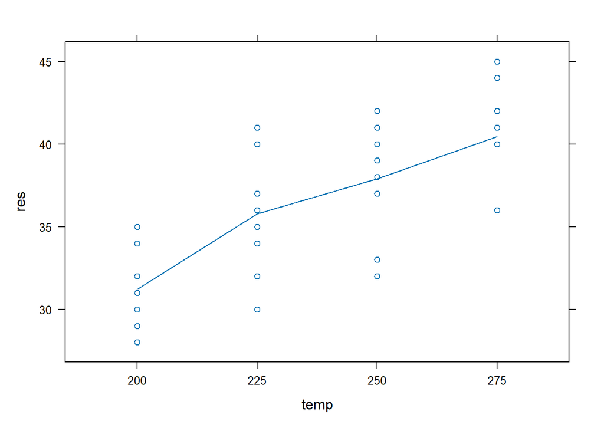

```r
xyplot(res~temp,type=c("a","p"),data=base)
```

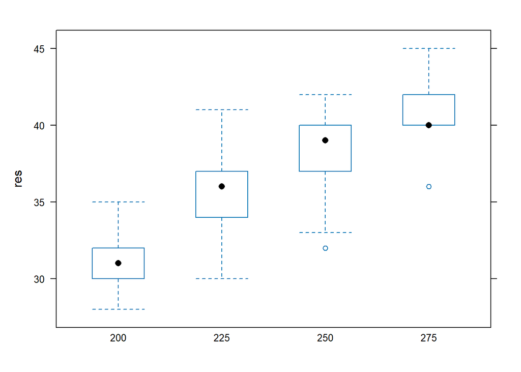

```r
bwplot(res~temp,data = base)
```

```r
emmeans(mod12, pairwise~temp, adjust="bonferroni")
```

```
## $emmeans
##  temp emmean   SE   df lower.CL upper.CL
##  200    31.2 1.13 5.11     28.3     34.1
##  225    35.8 1.13 5.11     32.9     38.7
##  250    37.9 1.13 5.11     35.0     40.8
##  275    40.4 1.13 5.11     37.6     43.3
##
## Results are averaged over the levels of: metodo
## Degrees-of-freedom method: kenward-roger
## Confidence level used: 0.95
##
## $contrasts
##  contrast          estimate   SE df t.ratio p.value
##  temp200 - temp225    -4.56 1.14 24  -4.001  0.0032
##  temp200 - temp250    -6.67 1.14 24  -5.854  <.0001
##  temp200 - temp275    -9.22 1.14 24  -8.099  <.0001
##  temp225 - temp250    -2.11 1.14 24  -1.854  0.4565
##  temp225 - temp275    -4.67 1.14 24  -4.098  0.0025
##  temp250 - temp275    -2.56 1.14 24  -2.244  0.2059
##
## Results are averaged over the levels of: metodo
## Degrees-of-freedom method: kenward-roger
## P value adjustment: bonferroni method for 6 tests
```

# DISEÑOS ANIDADOS

En este laboratorio se presentan dos ejercicios con factores anidados. Los dos ejercicios tienen una estructura similar. En el primer ejercicio llamado Escuelas, el factor fijo instructor está anidado dentro del factor fijo escuela, mientras que en el segundo llamado Cemento, el factor aleatorio barrica está anidado dentro del factor aleatorio lote. Cuando los factores son fijos se puede usar la función lm con una instrucción especial para indicar el anidamiento, y cuando los factores son aleatorios se utiliza la función lmer de la librería lme4 (Bates et al., 2015).

## Escuelas

Una compañía manufacturera tiene tres escuelas de mecánica regionales, una en cada una de sus regiones de operación. Cada escuela tiene dos instructores que dan cursos de tres semanas a 15 mecánicos aproximadamente. La compañía está interesada en conocer el efecto de la escuela (factor A) y el instructor (factor B) en el aprendizaje logrado. Se hace un experimento en el que se forman grupos en cada región y se asigna cada grupo a uno de los instructores. A cada instructor se le asignan dos grupos. Para determinar el efecto de la escuela y el instructor en el aprendizaje, se hace una prueba a los estudiantes y se obtiene el puntaje promedio del grupo como variable respuesta.

```r
load("bases/escuelas.Rdata")
base$escuela=factor(base$escuela)
levels(base$escuela)=c("D","K","Central")
base$instructor=factor(base$instructor)
base$instructor1=factor(base$instructor1)
```

• Haga una representación gráfica de los datos para ver el comportamiento de la respuesta según escuela e instructor. Use la función dotplot en la librería lattice de la siguiente forma: dotplot(puntaje ~ instructor | escuela). Hágalo usando tanto instructor como instructor1 y vea cuál de las dos formas es más conveniente.

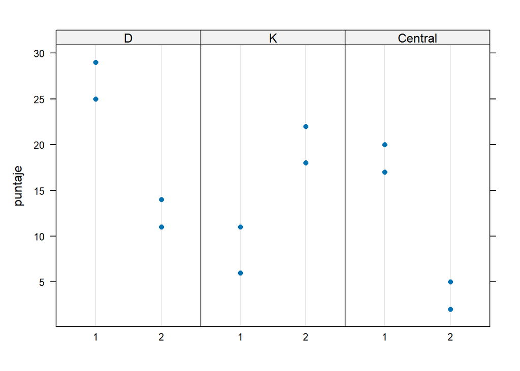

```r
library(lattice)
dotplot(puntaje~instructor|escuela,data = base)
```

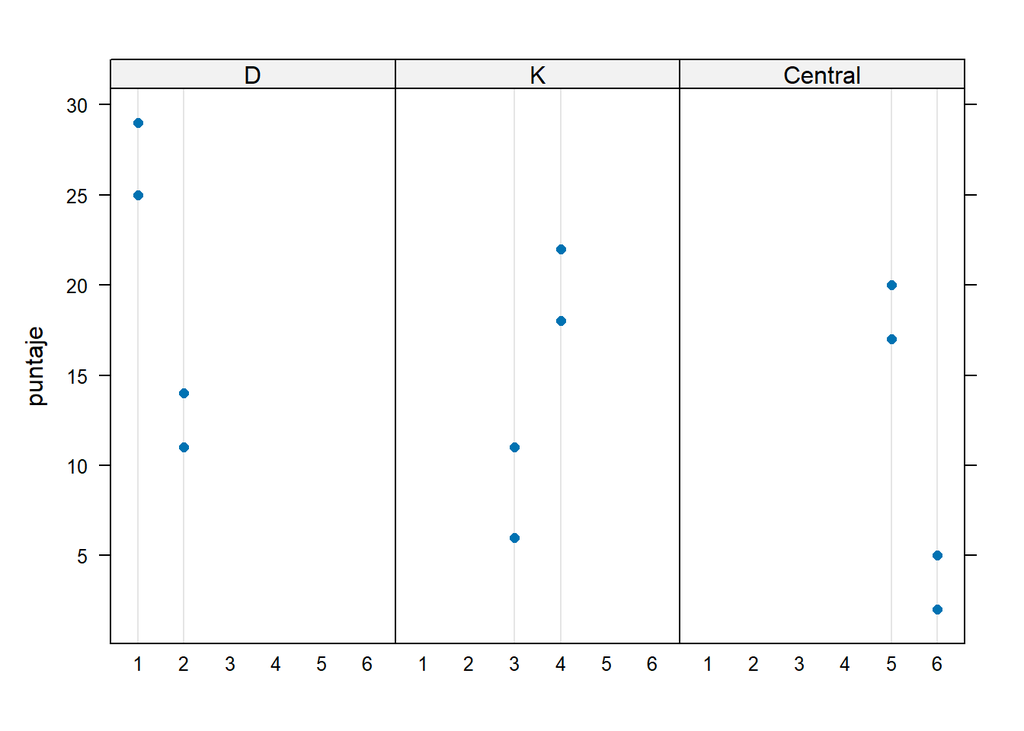

```r
dotplot(puntaje~instructor1|escuela,data = base)
```

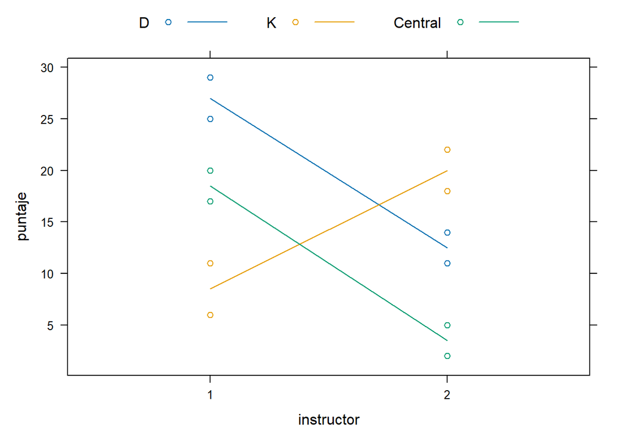

```r
xyplot(puntaje~instructor,groups = escuela,type=c("a","p"),data = base,auto.key = list(columns=3))
```

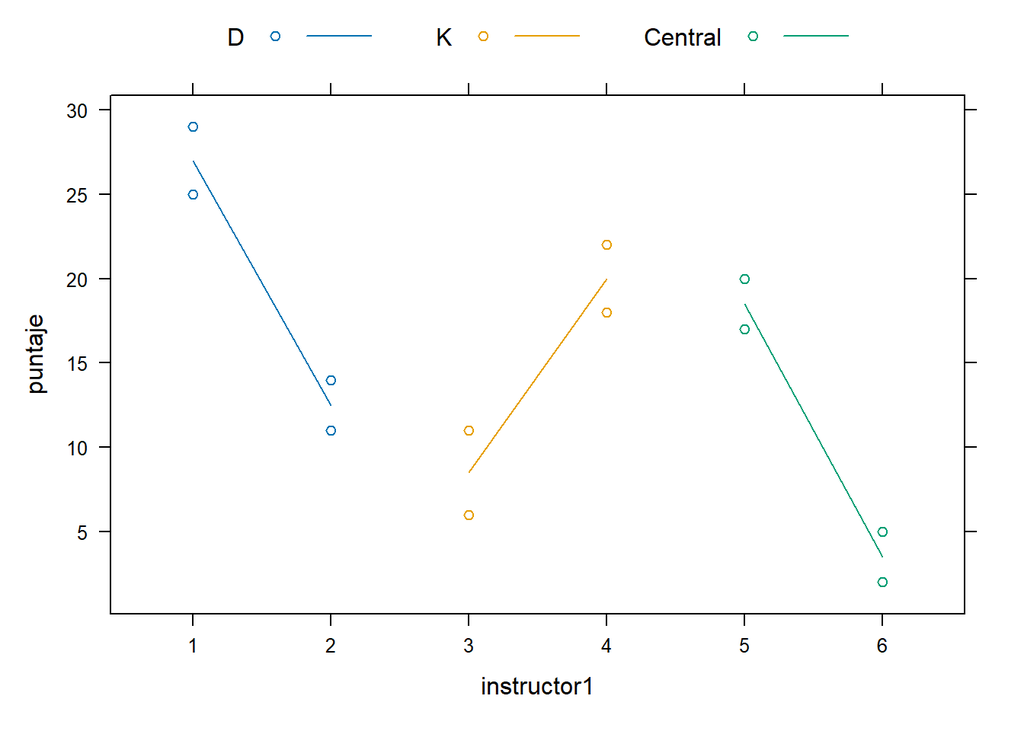

```r
xyplot(puntaje~instructor1,groups = escuela,type=c("a","p"),data = base,auto.key = list(columns=3))
```

• ¿Se puede esperar que exista interacción entre el instructor y la escuela?

No, no se analiza interacion en disenos anidados

• Comente si se espera que haya un efecto del instructor sobre el puntaje promedio dentro de cada escuela?

• Busque una forma de analizar gráficamente las diferencias entre escuelas. ¿Qué se puede concluir?

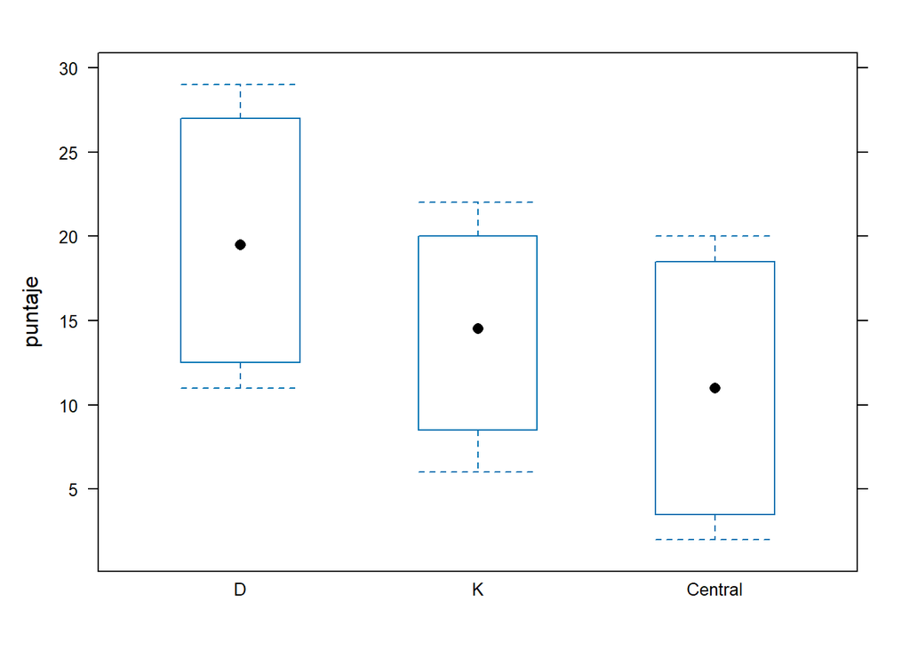

```r
bwplot(puntaje~escuela,data = base)
```

2. Efectos de instructor: • Obtenga manualmente los efectos de instructor dentro de escuela.

```r
media=tapply(base$puntaje,base$escuela,mean)
m=tapply(base$puntaje,list(base$instructor,base$escuela),mean)
in1=media-m[1,]
in2=media-m[2,]

h=rbind(in1,in2)
h
```

```
##         D     K Central
## in1 -7.25  5.75    -7.5
## in2  7.25 -5.75     7.5
```

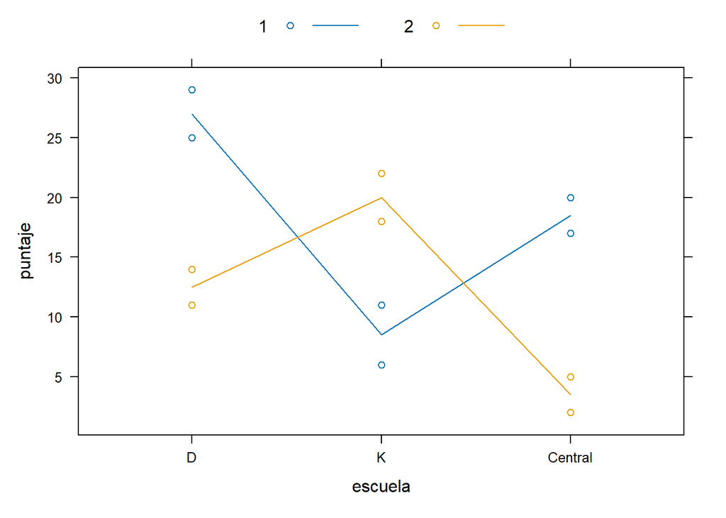

```r
xyplot(puntaje~escuela,groups = instructor,type=c("a","p"),data = base,auto.key = list(columns=2))
```

• Obtenga manualmente la suma de cuadrados de instructor dentro de escuela.

```r
r=2 #replicas
scres=sum(r*h^2);scres
```

```
## [1] 567.5
```

• ¿Cuántos grados de libertad tiene el factor anidado instructor?

```r
gl=(2-1)*3 #preguntar como obtener estos grados de libertad
#3 numero de escuelas
#2 numero de intructores
```

• Calcule el cuadrado medio de instructor dentro de escuela y explique su significado.

```r
scres/gl
```

```
## [1] 189.1667
```

3. Comparación de instructores. • Establezca con palabras la hipótesis nula al comparar los instructores.

todos los pares de promedios de los intructores dentro de las escuelas son iguales

• Se puede usar el factor anidado con el formato en que aparece instructor, pero indicando la estructura anidada dentro de la función lm de la siguiente forma: lm(puntaje~escuela+escuela/instructor). De esta forma se indica que el factor instructor está anidado dentro del factor escuela. Use el modelo de suma nula y llámelo mod5.

```r
options(contrasts=c("contr.sum","contr.poly"))
mod5=lm(puntaje~escuela/instructor,data = base)
```

• Obtenga el anova del modelo anidado y note que tiene una línea que parece una interacción que dice escuela:instructor, pero que en realidad debería leerse instructor(escuela), es decir, instructor dentro de escuela.

```r
anova(mod5)
```

```
## Analysis of Variance Table
##
## Response: puntaje
##                    Df Sum Sq Mean Sq F value   Pr(>F)
## escuela             2  156.5   78.25  11.179 0.009473 **
## escuela:instructor  3  567.5  189.17  27.024 0.000697 ***
## Residuals           6   42.0    7.00
## ---
## Signif. codes:  0 '***' 0.001 '**' 0.01 '*' 0.05 '.' 0.1 ' ' 1
```

• Observe el cuadrado medio de instructor y compárelo con el obtenido anteriormente. ¿Se rechaza la hipótesis nula referente al instructor?

• Obtenga los efectos de instructor.

```r
model.tables(aov(mod5))
```

```
## Tables of effects
##
##  escuela
## escuela
##       D       K Central
##    4.75   -0.75   -4.00
##
##  escuela:instructor
##          instructor
## escuela   1     2
##   D        7.25 -7.25
##   K       -5.75  5.75
##   Central  7.50 -7.50
```

5. Comparaciones entre instructores: • Obtenga los coeficientes del modelo.

```r
mod5$coefficients
```

```
##                (Intercept)                   escuela1
##                      15.00                       4.75
##                   escuela2       escuelaD:instructor1
##                      -0.75                       7.25
##       escuelaK:instructor1 escuelaCentral:instructor1
##                      -5.75                       7.50
```

• ¿A qué corresponden los últimos 3 coeficientes?

Estos 3 son los coeficientes del primer instructor dentro de la escuela

• Haga las comparaciones que tengan sentido entre los instructores. No tiene sentido comparar todos los pares de instructores, puesto que no todos pertenecen a las mismas escuelas. Por ejemplo, no tiene sentido comparar un instructor de la Región D con un instructor de la Región K. Use la corrección de Bonferroni con un nivel de significancia de 0.10 y confianza de 90%.

```r
coef=mod5$coefficients
#vectores
#para escuela D
ins1d=c(1,1,0,1,0,0)
ins2d=c(1,1,0,-1,0,0)
#para escuela K
ins1k=c(1,0,1,0,1,0)
ins2k=c(1,0,1,0,-1,0)
#para escuela central
ins1c=c(1,-1,-1,0,0,1)
ins2c=c(1,-1,-1,0,0,-1)

ins1d_ins2d=ins1d-ins2d
ins1k_ins2k=ins1k-ins2k
ins1c_ins2c=ins1c-ins2c

h=cbind(ins1d_ins2d,ins1k_ins2k,ins1c_ins2c)
L=t(h)%*%coef
L=abs(L)
#error
ee=sqrt(diag(t(h)%*%vcov(mod5)%*%h))
t=L/ee
gl=nrow(base)-length(coef)
p=pt(t,gl,lower.tail = F)
p>0.10
```

```
##              [,1]
## ins1d_ins2d FALSE
## ins1k_ins2k FALSE
## ins1c_ins2c FALSE
```

```r
round(p,3)
```

```
##              [,1]
## ins1d_ins2d 0.001
## ins1k_ins2k 0.002
## ins1c_ins2c 0.001
```

```r
emmeans(mod5, pairwise~instructor|escuela, adjust="bonferroni")
```

```
## NOTE: A nesting structure was detected in the fitted model:
##     instructor %in% escuela
```

```
## $emmeans
## escuela = D:
##  instructor emmean   SE df lower.CL upper.CL
##  1            27.0 1.87  6    22.42    31.58
##  2            12.5 1.87  6     7.92    17.08
##
## escuela = K:
##  instructor emmean   SE df lower.CL upper.CL
##  1             8.5 1.87  6     3.92    13.08
##  2            20.0 1.87  6    15.42    24.58
##
## escuela = Central:
##  instructor emmean   SE df lower.CL upper.CL
##  1            18.5 1.87  6    13.92    23.08
##  2             3.5 1.87  6    -1.08     8.08
##
## Confidence level used: 0.95
##
## $contrasts
## escuela = Central:
##  contrast                  estimate   SE df t.ratio p.value
##  instructor1 - instructor2     15.0 2.65  6   5.669  0.0013
##
## escuela = D:
##  contrast                  estimate   SE df t.ratio p.value
##  instructor1 - instructor2     14.5 2.65  6   5.480  0.0015
##
## escuela = K:
##  contrast                  estimate   SE df t.ratio p.value
##  instructor1 - instructor2    -11.5 2.65  6  -4.347  0.0048
```

cotas inferiores

```r
gl=nrow(base)-length(coef)
alpha=0.10
qt=qt(1-alpha,gl); LIM=L-qt*ee
row.names(LIM)=row.names(p)
round(LIM,1)
```

```
##             [,1]
## ins1d_ins2d 10.7
## ins1k_ins2k  7.7
## ins1c_ins2c 11.2
```

6. Haga las comparaciones entre las diferentes escuelas usando Tukey con 10% de significancia en pruebas de una cola.

```r
#porque me da diferente a tukey !!!!!
coef=mod5$coefficients
#vectores
#para escuela D
esd=c(1,1,0,0,0,0)
#para escuela K
esk=c(1,0,1,0,0,0)
#para escuela central
esc=c(1,-1,-1,0,0,0)

esd_esk=esd-esk
esd_esc=esd-esc
esk_esc=esk-esc

h=cbind(esd_esk,esd_esc,esk_esc)
L=t(h)%*%coef
L=abs(L)
#error
ee=sqrt(diag(t(h)%*%vcov(mod5)%*%h))
t=L/ee
gl=nrow(base)-length(coef)
p=pt(t,gl,lower.tail = F)
k=3
p>0.10/k
```

```
##          [,1]
## esd_esk FALSE
## esd_esc FALSE
## esk_esc  TRUE
```

```r
round(p,3)
```

```
##          [,1]
## esd_esk 0.013
## esd_esc 0.002
## esk_esc 0.067
```

```r
#!!!!!! preguntar porque aqui en la solucion no se hace la correcion de bonferroni
```

```r
#3 numero de contrastes !!!! preguntar si es lo correcto
ptukey(t*sqrt(2),3,gl,lower.tail = F)
```

```
##                [,1]
## esd_esk 0.058612875
## esd_esc 0.008122427
## esk_esc 0.267659579
```

```r
emmeans(mod5, pairwise~escuela, adjust="bonferroni")
```

```
## NOTE: A nesting structure was detected in the fitted model:
##     instructor %in% escuela
```

```
## NOTE: Results may be misleading due to involvement in interactions
```

```
## $emmeans
##  escuela emmean   SE df lower.CL upper.CL
##  D         19.8 1.32  6    16.51     23.0
##  K         14.2 1.32  6    11.01     17.5
##  Central   11.0 1.32  6     7.76     14.2
##
## Results are averaged over the levels of: instructor
## Confidence level used: 0.95
##
## $contrasts
##  contrast    estimate   SE df t.ratio p.value
##  D - K           5.50 1.87  6   2.940  0.0779
##  D - Central     8.75 1.87  6   4.677  0.0102
##  K - Central     3.25 1.87  6   1.737  0.3991
##
## Results are averaged over the levels of: instructor
## P value adjustment: bonferroni method for 3 tests
```

• Obtenga cotas inferiores de 90% de confianza para la diferencia de medias entre los pares de escuelas en que encontró diferencias.

```r
gl=nrow(base)-length(coef)
alpha=0.10
qt=qt(1-alpha/2,gl); LIM=L-qt*ee
row.names(LIM)=row.names(p)
LIM=LIM[-3,]
round(LIM,3)
```

```
## esd_esk esd_esc
##   1.865   5.115
```

```r
#aqui hay un error en la solucion ya que K-central no era significativa es d-centra
```

7. ¿Cómo se alteran las conclusiones si se considera que hay muchos instructores en cada región y en el experimento los que participaron fueron una muestra?

```r
#!!! porque en este analisis la escuela se toma como un efecto aleatorio tambien
mod2=lmer(puntaje~1+(1|escuela)+(1|instructor1),data=base)
```

```
## boundary (singular) fit: see help('isSingular')
```

```r
mod22=lmer(puntaje~1+(1|escuela),data=base)
summary(mod2)
```

```
## Linear mixed model fit by REML ['lmerMod']
## Formula: puntaje ~ 1 + (1 | escuela) + (1 | instructor1)
##    Data: base
##
## REML criterion at convergence: 70.3
##
## Scaled residuals:
##      Min       1Q   Median       3Q      Max
## -1.06368 -0.62561 -0.07309  0.67971  0.97519
##
## Random effects:
##  Groups      Name        Variance  Std.Dev.
##  instructor1 (Intercept) 6.890e+01 8.301e+00
##  escuela     (Intercept) 2.903e-16 1.704e-08
##  Residual                7.000e+00 2.646e+00
## Number of obs: 12, groups:  instructor1, 6; escuela, 3
##
## Fixed effects:
##             Estimate Std. Error t value
## (Intercept)   15.000      3.474   4.318
## optimizer (nloptwrap) convergence code: 0 (OK)
## boundary (singular) fit: see help('isSingular')
```

```r
anova(mod2,mod22)
```

```
## refitting model(s) with ML (instead of REML)
```

```
## Data: base
## Models:
## mod22: puntaje ~ 1 + (1 | escuela)
## mod2: puntaje ~ 1 + (1 | escuela) + (1 | instructor1)
##       npar    AIC    BIC  logLik deviance  Chisq Df Pr(>Chisq)
## mod22    3 89.930 91.385 -41.965   83.930
## mod2     4 82.488 84.428 -37.244   74.488 9.4417  1   0.002121 **
## ---
## Signif. codes:  0 '***' 0.001 '**' 0.01 '*' 0.05 '.' 0.1 ' ' 1
```

```r
confint(mod2)
```

```
## Computing profile confidence intervals ...
```

```
##                2.5 %    97.5 %
## .sig01      4.374292 15.463474
## .sig02      0.000000 11.487301
## .sigma      1.643105  5.306366
## (Intercept) 7.501444 22.498690
```

El intervalo de confianza para la desviación estándar de los coeficientes de escuela limita con el cero, lo cual hace que no se rechace la hipótesis nula referente a la igualdad de medias entre escuelas. Sin embargo, se siguen viendo diferencias entre los instructores dentro de escuelas pero no interesa comparar los instructores de forma específica.

# Cemento

El cemento es el material más activo de la mezcla de concreto, por tanto sus características y sobre todo su contenido (proporción) dentro de la mezcla tienen una gran influencia en la resistencia del concreto a cualquier edad. La resistencia a la compresión simple es la característica mecánica principal del concreto. Se define como la capacidad para soportar una carga por unidad de área, y se expresa en términos de esfuerzo, generalmente en kg/cm2.

Un experimento trata de analizar la calidad en la producción de cemento, el cual se produce por lotes y se empaca en sacos. Se sospecha que hay variabilidad entre los lotes en que se ha producido el cemento, así como puede haberla entre los sacos provenientes de cada lote. Rutinariamente se seleccionan aleatoriamente 3 sacos de cada lote para tenerlas como referencia. Se escogen aleatoriamente 10 lotes y se hacen 2 pruebas analíticas de resistencia de cada una de los 30 sacos resultantes.

Ejercicios 1. Justifique si los factores están cruzados o anidados. 2. Cuando los factores están anidados se debe tener cuidado con la definición del factor anidado, ya que no pueden repetirse los niveles de este factor en los diferentes niveles del factor externo. Abra el archivo cemento.Rdata, observe que los sacos tienen los mismos nombres en todos los lotes. Para comprender los datos haga una tabla cruzada de las variables lote y saco.

```r
load("bases/cemento.Rdata")
table(base$lote,base$saco)
```

```
##
##     a b c
##   A 2 2 2
##   B 2 2 2
##   C 2 2 2
##   D 2 2 2
##   E 2 2 2
##   F 2 2 2
##   G 2 2 2
##   H 2 2 2
##   I 2 2 2
##   J 2 2 2
```

• Puede cruzar las dos variables y hacer una nueva variable llamada saco1 usando la combinación de ambas variables: base$lote:base$saco.

```r
base$saco1=base$lote:base$saco
```

• Obtenga la tabla cruzada de lote y saco1. Note la diferencia.

```r
table(base$saco1,base$lote)
```

```
##
##       A B C D E F G H I J
##   A:a 2 0 0 0 0 0 0 0 0 0
##   A:b 2 0 0 0 0 0 0 0 0 0
##   A:c 2 0 0 0 0 0 0 0 0 0
##   B:a 0 2 0 0 0 0 0 0 0 0
##   B:b 0 2 0 0 0 0 0 0 0 0
##   B:c 0 2 0 0 0 0 0 0 0 0
##   C:a 0 0 2 0 0 0 0 0 0 0
##   C:b 0 0 2 0 0 0 0 0 0 0
##   C:c 0 0 2 0 0 0 0 0 0 0
##   D:a 0 0 0 2 0 0 0 0 0 0
##   D:b 0 0 0 2 0 0 0 0 0 0
##   D:c 0 0 0 2 0 0 0 0 0 0
##   E:a 0 0 0 0 2 0 0 0 0 0
##   E:b 0 0 0 0 2 0 0 0 0 0
##   E:c 0 0 0 0 2 0 0 0 0 0
##   F:a 0 0 0 0 0 2 0 0 0 0
##   F:b 0 0 0 0 0 2 0 0 0 0
##   F:c 0 0 0 0 0 2 0 0 0 0
##   G:a 0 0 0 0 0 0 2 0 0 0
##   G:b 0 0 0 0 0 0 2 0 0 0
##   G:c 0 0 0 0 0 0 2 0 0 0
##   H:a 0 0 0 0 0 0 0 2 0 0
##   H:b 0 0 0 0 0 0 0 2 0 0
##   H:c 0 0 0 0 0 0 0 2 0 0
##   I:a 0 0 0 0 0 0 0 0 2 0
##   I:b 0 0 0 0 0 0 0 0 2 0
##   I:c 0 0 0 0 0 0 0 0 2 0
##   J:a 0 0 0 0 0 0 0 0 0 2
##   J:b 0 0 0 0 0 0 0 0 0 2
##   J:c 0 0 0 0 0 0 0 0 0 2
```

3. Haga un gráfico para ver el comportamiento de la respuesta en los sacos de cada lote.

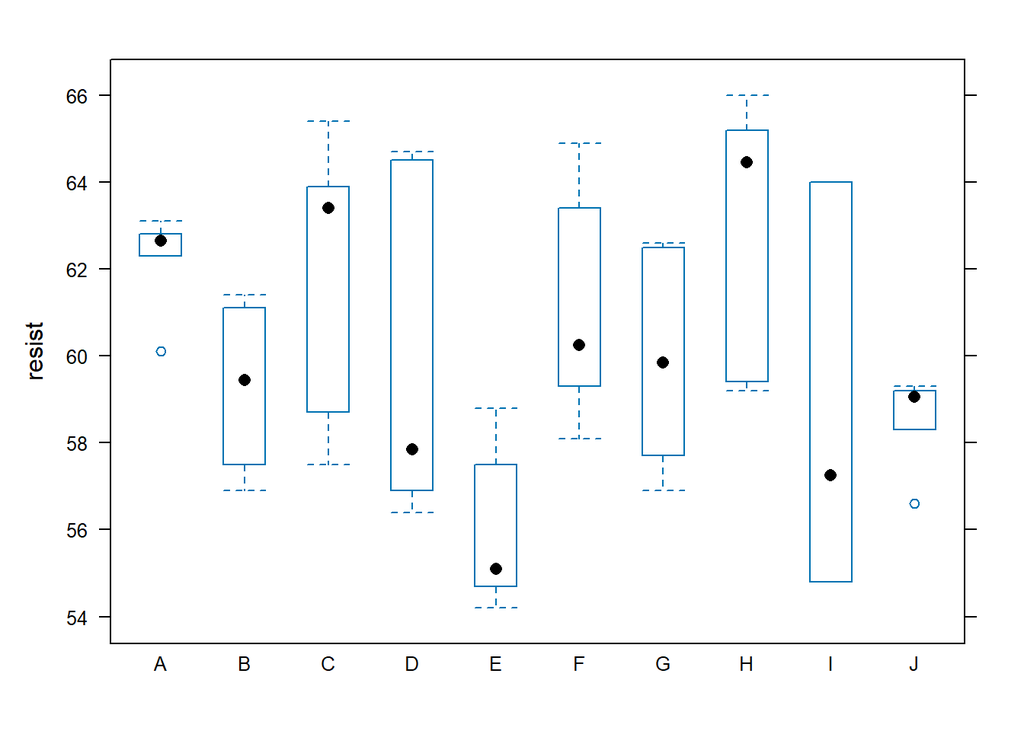

```r
bwplot(resist~lote,data = base)
```

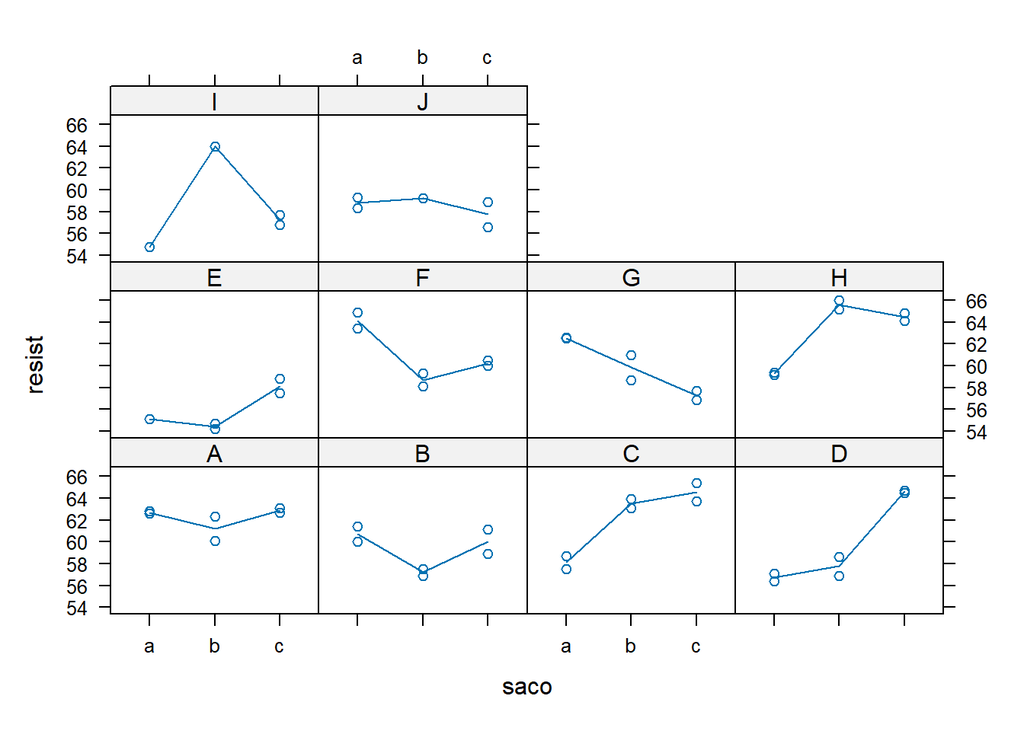

```r
xyplot(resist~saco|lote,type=c("a","p"),data=base)
```

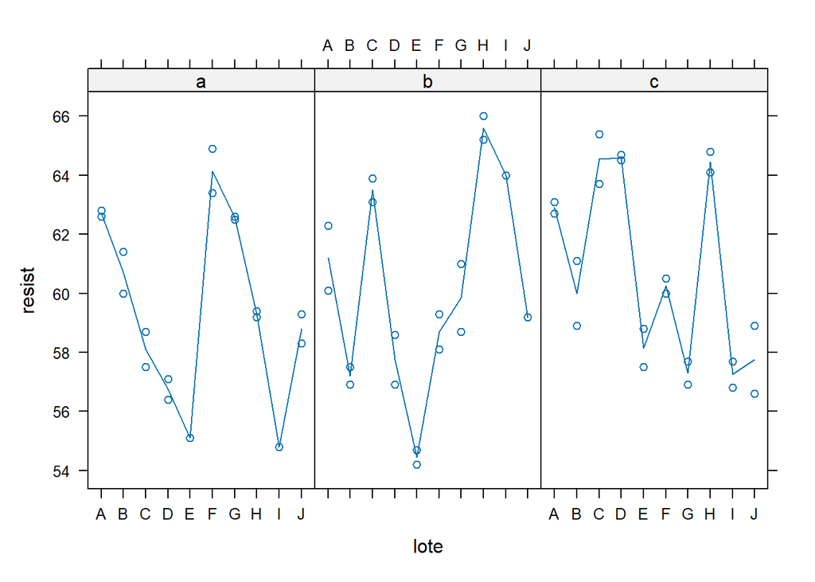

```r
xyplot(resist~lote|saco,type=c("a","p"),data=base)
```

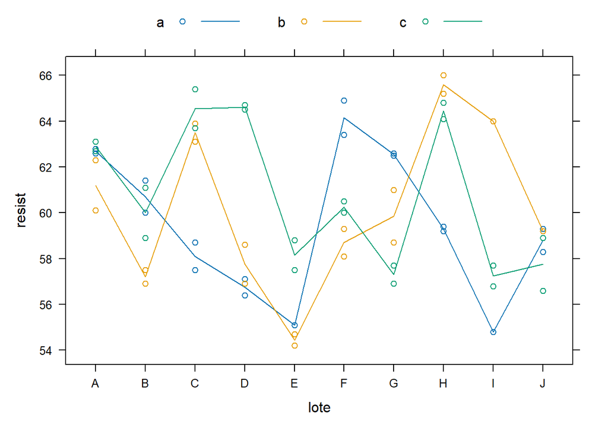

```r
xyplot(resist~lote,groups=saco,type=c("a","p"),data=base,auto.key = list(columns=3))
```

4. Analice las fuentes de variabilidad que pueden estar incidiendo en la resistencia del cemento. Haga el análisis de diversas formas. ¿Son consistentes los resultados obtenidos con los diferentes enfoques?

```r
#!!! porque aqui obtengo los mismo resultados
mod1=lmer(resist~(1|lote)+(1|saco1),data = base)
mod2=lmer(resist~(1|lote)+(1|lote:saco),data = base)
summary(mod1)
```

```
## Linear mixed model fit by REML ['lmerMod']
## Formula: resist ~ (1 | lote) + (1 | saco1)
##    Data: base
##
## REML criterion at convergence: 247
##
## Scaled residuals:
##     Min      1Q  Median      3Q     Max
## -1.4798 -0.5156  0.0095  0.4720  1.3897
##
## Random effects:
##  Groups   Name        Variance Std.Dev.
##  saco1    (Intercept) 8.434    2.9041
##  lote     (Intercept) 1.657    1.2874
##  Residual             0.678    0.8234
## Number of obs: 60, groups:  saco1, 30; lote, 10
##
## Fixed effects:
##             Estimate Std. Error t value
## (Intercept)  60.0533     0.6769   88.72
```

```r
summary(mod2)
```

```
## Linear mixed model fit by REML ['lmerMod']
## Formula: resist ~ (1 | lote) + (1 | lote:saco)
##    Data: base
##
## REML criterion at convergence: 247
##
## Scaled residuals:
##     Min      1Q  Median      3Q     Max
## -1.4798 -0.5156  0.0095  0.4720  1.3897
##
## Random effects:
##  Groups    Name        Variance Std.Dev.
##  lote:saco (Intercept) 8.434    2.9041
##  lote      (Intercept) 1.657    1.2874
##  Residual              0.678    0.8234
## Number of obs: 60, groups:  lote:saco, 30; lote, 10
##
## Fixed effects:
##             Estimate Std. Error t value
## (Intercept)  60.0533     0.6769   88.72
```

```r
#variabilidad
err=0.678
lote=1.657
saco=8.434
total=err+lote+saco

(cbind(err,lote,saco)/total)*100
```

```
##           err     lote     saco
## [1,] 6.295849 15.38676 78.31739
```

```r
confint(mod1)
```

```
## Computing profile confidence intervals ...
```

```
##                  2.5 %    97.5 %
## .sig01       2.1579337  4.053589
## .sig02       0.0000000  2.946591
## .sigma       0.6520234  1.085448
## (Intercept) 58.6636504 61.443016
```

```r
confint(mod2)
```

```
## Computing profile confidence intervals ...
```

```
##                  2.5 %    97.5 %
## .sig01       2.1579337  4.053589
## .sig02       0.0000000  2.946591
## .sigma       0.6520234  1.085448
## (Intercept) 58.6636504 61.443016
```

probar efecto del saco

```r
mod1=lmer(resist~(1|lote)+(1|saco1),data = base)
mod11=lmer(resist~(1|lote),data = base)
anova(mod1,mod11,test="LRT")
```

```
## refitting model(s) with ML (instead of REML)
```

```
## Data: base
## Models:
## mod11: resist ~ (1 | lote)
## mod1: resist ~ (1 | lote) + (1 | saco1)
##       npar    AIC    BIC logLik deviance  Chisq Df Pr(>Chisq)
## mod11    3 308.60 314.88 -151.3   302.60
## mod1     4 255.99 264.37 -124.0   247.99 54.605  1  1.474e-13 ***
## ---
## Signif. codes:  0 '***' 0.001 '**' 0.01 '*' 0.05 '.' 0.1 ' ' 1
```

efecto de lote

```r
mod1=lmer(resist~(1|lote)+(1|saco1),data = base)
mod11=lmer(resist~(1|saco1),data = base)
anova(mod1,mod11,test="LRT")
```

```
## refitting model(s) with ML (instead of REML)
```

```
## Data: base
## Models:
## mod11: resist ~ (1 | saco1)
## mod1: resist ~ (1 | lote) + (1 | saco1)
##       npar    AIC    BIC logLik deviance  Chisq Df Pr(>Chisq)
## mod11    3 254.40 260.69 -124.2   248.40
## mod1     4 255.99 264.37 -124.0   247.99 0.4072  1     0.5234
```

```r
mod1=lmer(resist~(1|lote)+(1|saco1),data = base)
mod11=lmer(resist~(1|lote:saco),data = base)
anova(mod1,mod11,test="LRT")
```

```
## refitting model(s) with ML (instead of REML)
```

```
## Data: base
## Models:
## mod11: resist ~ (1 | lote:saco)
## mod1: resist ~ (1 | lote) + (1 | saco1)
##       npar    AIC    BIC logLik deviance  Chisq Df Pr(>Chisq)
## mod11    3 254.40 260.69 -124.2   248.40
## mod1     4 255.99 264.37 -124.0   247.99 0.4072  1     0.5234
```